# Forecasting Methods Project

Group

01/05/2022

## 1. Introduction

In this work, the group will focus on the analysis of temperature changes over the last three centuries, from 1800 to 2015. We have chosen this variable because climate change and global warming are one of the biggest problems the world is facing today. With this project, we expect to gain more knowledge about how temperature has behaved over the years, especially in this last century with global warming. We aim to understand how temperature patterns differ across countries and continents, identify seasonal variations and trend patterns. Moreover, we will explore different prediction methods hoping to find a model that best fits our data and provides higher accuracy.

Our time-series dataset ranges from about 1800 to 2015. Since it is monthly data, it contains some NAs, especially in the earliest years of available data. The dataset provides us with a land average temperature for each country as well as a global perspective with land average temperature, ocean & land average temperature and the associated uncertainty value. The maximum and minimum values for land temperature are also given. The dataset comes from the Berkeley Earth website, which has compiled temperature records.

In this report, we will follow certain steps to achieve our desired goals. First, we explore the dataset by creating time series graphs and analyzing them. In this way, we aim to identify possible patterns such as trends, cycles and seasonal fluctuations over time. Then, common methods to extract these components are applied in order to improve the forecast accuracy thereafter. In chapter 4 we will use several benchmark forecasting methods to forecast our time series and assess forecast accuracy. In the following to sections first the most appropriate Exponential Smooting Methods and then ARIMA Models are applied. Finally, we will compare the different models in a conclusion and summarize our results.

```r
GlobalTemp
```

```
## # A tsibble: 1,992 x 8 [1M]
## # Key:       Country [1]
##        Date Country LandAvgTemp LandAvgTempUnc LandMaxTemp LandMinTemp
##       <mth> <chr>         <dbl>          <dbl>       <dbl>       <dbl>
##  1 1850 jan Global        0.749          1.10         8.24       -3.21
##  2 1850 fev Global        3.07           1.27         9.97       -2.29
##  3 1850 mar Global        4.95           0.955       10.3        -1.90
##  4 1850 abr Global        7.22           0.665       12.9         1.02
##  5 1850 mai Global       10.0            0.617       15.7         3.81
##  6 1850 jun Global       13.2            0.614       18.9         7.11
##  7 1850 jul Global       14.5            0.614       19.2         8.01
##  8 1850 ago Global       14.0            0.802       18.5         7.41
##  9 1850 set Global       11.5            0.675       15.8         4.53
## 10 1850 out Global        8.09           0.863       13.2         2.01
## # ... with 1,982 more rows, and 2 more variables: LandOceanAvgTemp <dbl>,
## #   LandOceanAvgTempUnc <dbl>
```

```r
GlobalCountryTemp %>% select(Date, Country, LandAvgTemp)
```

```
## # A tsibble: 580,654 x 3 [1M]
## # Key:       Country [244]
##        Date Country     LandAvgTemp
##       <mth> <chr>             <dbl>
##  1 1838 abr Afghanistan       13.0
##  2 1838 mai Afghanistan       NA
##  3 1838 jun Afghanistan       24.0
##  4 1838 jul Afghanistan       26.9
##  5 1838 ago Afghanistan       24.9
##  6 1838 set Afghanistan       19.0
##  7 1838 out Afghanistan       13.4
##  8 1838 nov Afghanistan        7.48
##  9 1838 dez Afghanistan       NA
## 10 1839 jan Afghanistan       NA
## # ... with 580,644 more rows
```

## 2. Time series graphics

In this section, the group explores the dataset by creating time series graphics and analyzing them. This part is very important as it provides the group with an overall view of temperature changes over time and allows them to identify possible patterns such as trends, cycles and seasonal variation over time.

### General overview of the dataset

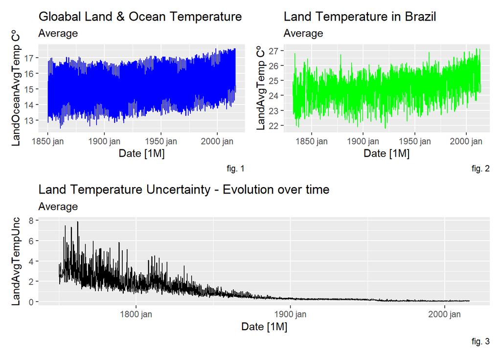

```r
Fig1 <- GlobalTemp %>% autoplot(LandOceanAvgTemp)+
  geom_line(color="blue")+
  labs(title = "Gloabal Land & Ocean Temperature",
       subtitle = "Average",
       y="LandOceanAvgTemp Cº",
       caption = "fig. 1")

Fig2 <- GlobalCountryTemp %>% filter(Country == "Brazil") %>% autoplot(LandAvgTemp)+
  geom_line(color="green")+
  labs(title = "Land Temperature in Brazil",
       subtitle="Average",
       y="LandAvgTemp Cº",
       caption = "fig. 2")

Fig3 <- GlobalCountryTemp %>% filter(Country=="Global") %>% autoplot(LandAvgTempUnc)+
  labs(title = "Land Temperature Uncertainty - Evolution over time",
       subtitle="Average",
       caption = "fig. 3")

(Fig1 | Fig2 ) / Fig3
```

The dataset provides three different views that can be combined and analysed in multiple different ways.

The first view is the global land & ocean average temperature (see fig. 1). It provides an interesting overview on how the combination of both land and ocean temperature has been changing since 1850.

The central view of the dataset is the land temperature analysis, which can be divided into two parts:

- A global analysis that contains average, max and min temperature values
- A more narrow analysis by country that allows us to observe particular average temperatures over the years by country. Note that the years analysed may differ from country to country due to missing data in the dataset, especially for years before 1900. Figure 2 shows the time series of Land Temperature of Brazil to illustrate the time series of one country as an example.

The final view is related with the uncertainty of the average temperature values and how it has changed over time (see fig. 3).

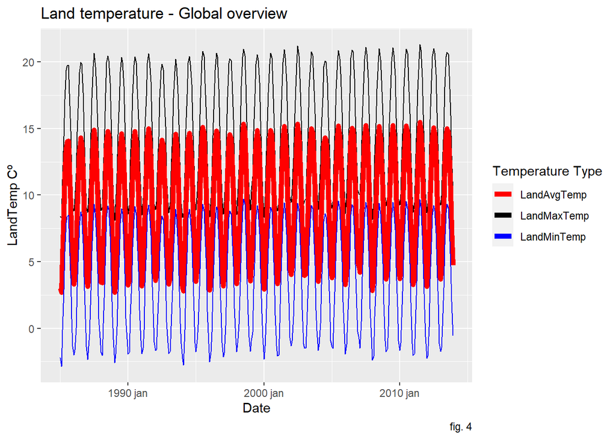

```r
GlobalTempV %>% ggplot()+
  geom_line(data=GlobalTempV, aes(Date, LandMaxTemp, col="LandMaxTemp"))+
  geom_line(data=GlobalTempV, aes(Date,LandAvgTemp,col="LandAvgTemp"),lwd=2)+
  geom_line(data=GlobalTempV, aes(Date, LandMinTemp, col="LandMinTemp"))+
  labs(title = "Land temperature - Global overview",
       y="LandTemp Cº",
       color="Temperature Type",
       caption = "fig. 4")+
  scale_color_manual(values= c("red","black","blue"))
```

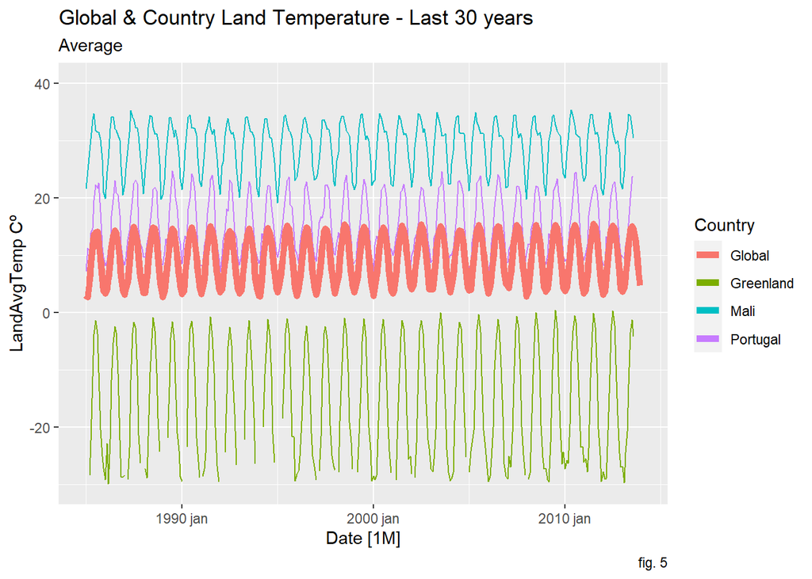

```r
GlobalCountryTemp %>% filter(Country %in% countries) %>% filter(year(Date)>1984) %>% autoplot(LandAvgTemp)+
  geom_line(data=GlobalTempV ,aes(Date, LandAvgTemp, col= "Global"),lwd=2)+
  labs(title= "Global & Country Land Temperature - Last 30 years",
            subtitle = "Average",
            y= "LandAvgTemp Cº",
       caption = "fig. 5")+
  ylim(-30,40)+
  theme(legend.position = "right")
```

Figure 5 shows the average temperature in the last 30 years of three selected countries and “global”. By looking at these time series, we can see that the temperature behaves differently depending on the country analysed. Some countries belong to hot regions like Mali and even Portugal and therefore have higher temperatures while other countries like Greenland are in more northern zones and have colder temperatures. The global temperature is nothing more than the weighted average of the temperature of all countries in the original dataset and therefore it appears in the “middle” of the time series graph. The same reasoning can be applied to the max and min global temperature in figure 4.

When we take a closer look to these graphs it’s possible to start observing some seasonal and trending patterns. Regarding the trending patterns, we can clearly see a very smooth crescent trend when it comes to land and ocean temperatures (fig. 1), which makes sense as a result of a direct effect of the global warming in the temperature, making it rise. On the other hand, there is a clear downward trend on the temperature uncertainty (fig. 3), which makes sense as temperature measurement methods become better and more accurate over time.

Looking now at the seasonal pattern, when we highlight the two graphs starting from 1985 onwards (fig. 4 and 5), it becomes explicit that there is a seasonal behavior every year. There are four seasons (winter, spring, summer and autumn) and we can clearly see that each of those has its temperature characteristics.

### Focusing on seasonality, cycles and trends

In this section, the objective is to focus on the seasonal and trending pattern identified previously and confirm them.

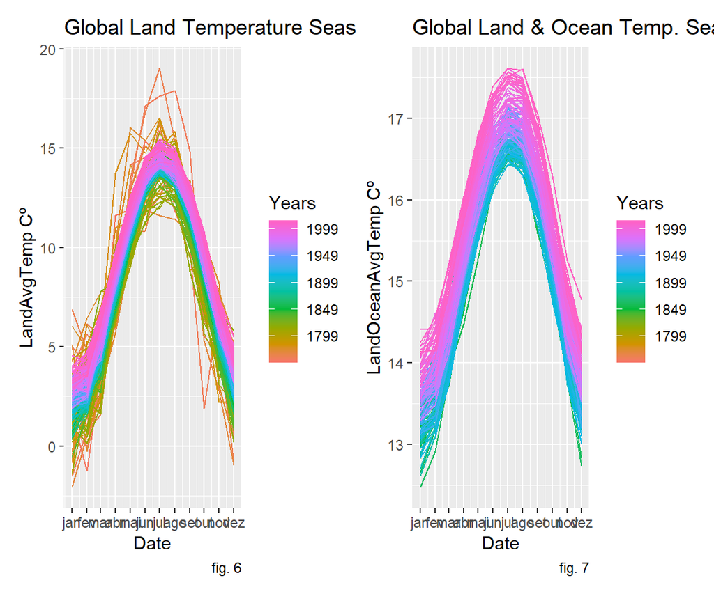

```r
#seasonal and trending
Fig6 <-GlobalCountryTemp %>%
  filter(Country=="Global") %>%
  gg_season(LandAvgTemp)+
  labs(title = "Global Land Temperature Seasonality",
       y="LandAvgTemp Cº",
       color="Years",
       caption = "fig. 6")

Fig7<- GlobalCountryTemp %>%
  filter(Country=="Global") %>%
  gg_season(LandOceanAvgTemp)+
  labs(title = "Global Land & Ocean Temp. Seasonality",
       y="LandOceanAvgTemp Cº",
       color="Years",
       caption = "fig. 7")

Fig6 + Fig7
```

The two graphs above give us some interesting insights into the seasonality observed previously.

We can clearly see that in winter months (December, January and February), the temperature reaches the lowest values while in summer months (June, July, August), the temperature reaches its peak. Besides showing the seasonality, this graph shows the crescent trending as the years go by. The lines that represent the years keep going up in the graph.

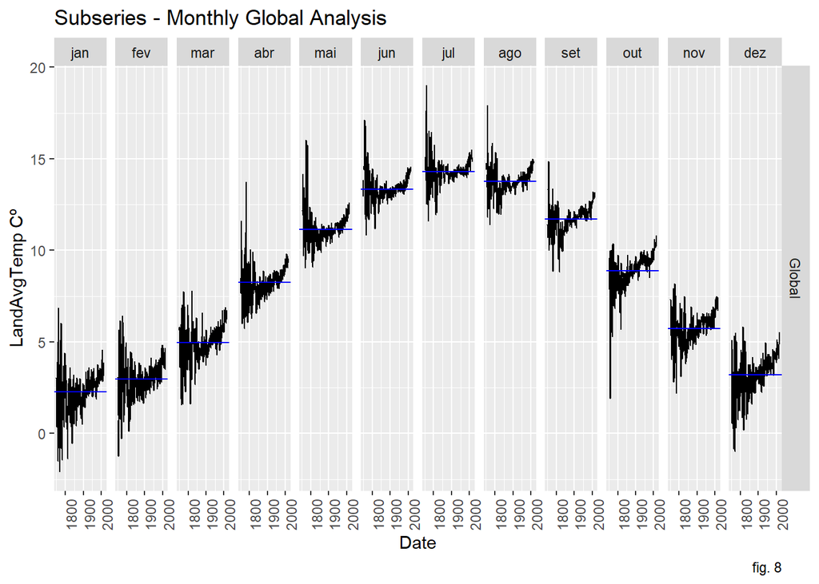

```r
#subseries
GlobalCountryTemp %>%
  filter(Country=="Global") %>%
  gg_subseries(LandAvgTemp)+
  labs(title = "Subseries - Monthly Global Analysis",
       y="LandAvgTemp Cº",
       caption = "fig. 8")
```

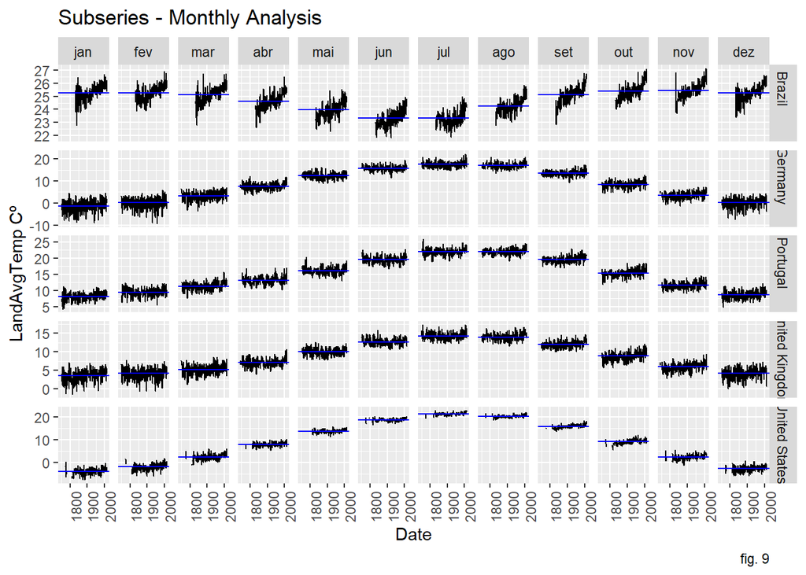

```r
GlobalCountryTemp %>%
  filter(Country %in% countries2) %>%
  gg_subseries(LandAvgTemp)+
  labs(title = "Subseries - Monthly Analysis",
         y="LandAvgTemp Cº",
       caption = "fig. 9")
```

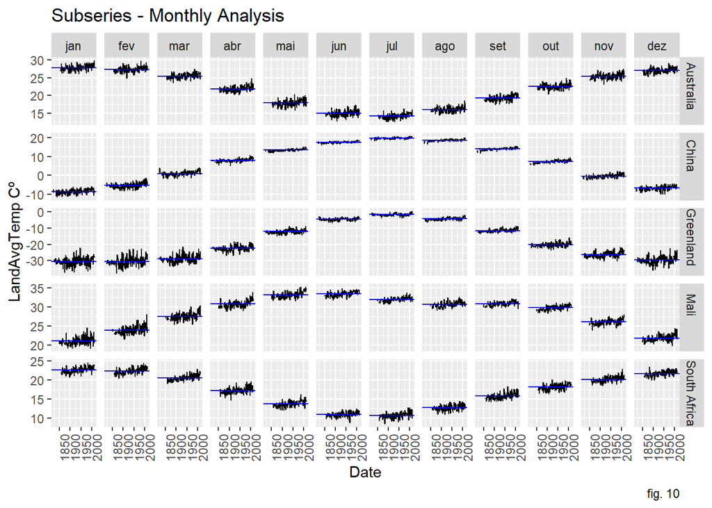

```r
GlobalCountryTemp %>%
  filter(Country %in% countries3) %>%
  gg_subseries(LandAvgTemp)+
  labs(title = "Subseries - Monthly Analysis",
         y="LandAvgTemp Cº",
       caption = "fig. 10")
```

The subseries analysis also provides some more details about seasonality and trend.

Especially figure 8 shows clearly high discrepancies in early 1800 temperature values due to the high uncertainty. However, it is still clear that the trend is increasing globally.

The country subseries analysis in figure 9 and 10 reveals again a strong seasonality. However, it also shows a new perspective regarding the seasonality. Some countries have their seasonality “swaped” when compared to the global seasonality. This is due to the fact that the temperature in the countries of the northern hemisphere is the opposite of that in the countries of the southern hemisphere: If it’s summer in the north (June, July, August), it’s winter in the south. Nevertheless we can still identify the growing trend of the temperature in most countries.

### Looking at autocorrelation and white noise

Lastly, we analyse the autocorrelation and examine whether white noise exists.

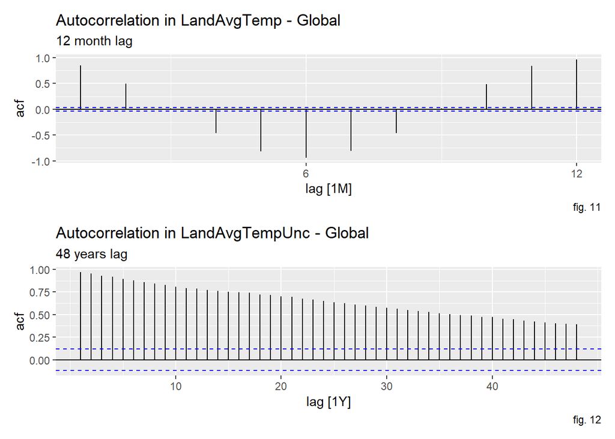

```r
#6, 12 or 24 lags--> monthly data
#In this case 12 looks the best as it captures all months of one year

Fig11 <-GlobalCountryTemp %>% filter(Country=="Global") %>% ACF(LandAvgTemp,lag_max = 12) %>% autoplot()+
  labs(title = "Autocorrelation in LandAvgTemp - Global",
       subtitle = "12 month lag",
       caption = "fig. 11")

Fig13 <-GlobalCountryTemp %>%
  filter(Country %in% countries2)%>% ACF(LandAvgTemp,lag_max = 12) %>% autoplot()+
  labs(title = "Autocorrelation in LandAvgTemp - Country",
       subtitle = "12 month lag",
       caption = "fig. 13")

#transforming it into yearly data since there is no seasonality
#showing the first 48 years
uncertainty<- GlobalCountryTemp %>% filter(Country=="Global") %>%
  mutate(Year= year(Date)) %>%
  as_tibble(GlobalCountryTemp) %>%
  group_by(Year)%>%
  select(-Date) %>%
  summarise(LandAvgTempUnc= mean(LandAvgTempUnc))

Fig12 <-uncertainty %>%as_tsibble(index=Year) %>% filter(Year> "1752") %>%
  ACF(LandAvgTempUnc, lag_max = 48) %>% autoplot()+
  labs(title = "Autocorrelation in LandAvgTempUnc - Global",
       subtitle = "48 years lag",
       caption = "fig. 12")

(Fig11 / Fig12)
```

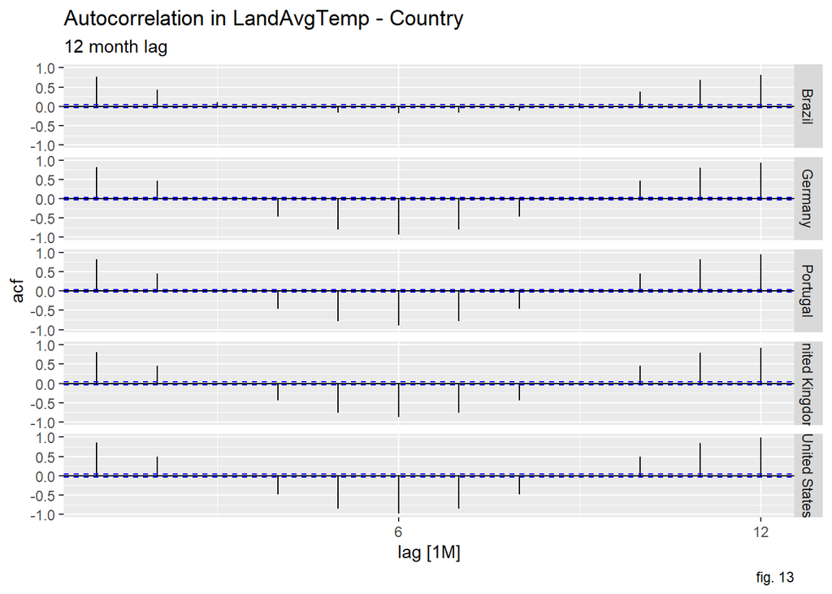

```r
Fig13
```

Since our autocorrelation values are mostly above the significant interval our time series don’t follow “white noise”.

## 3. Time Series Decomposition

First of all, we replaced missing values, by the last available value for that variable (in an up-down manner), so that we keep our time series without missing gaps, to be able to decompose it.

```r
GlobalCountryTemp %>%
  fill(LandAvgTemp, .direction = 'down') %>%
  fill(LandOceanAvgTemp, .direction = 'down') -> GlobalCountryTemp

#colSums(is.na(GlobalCountryTemp))
```

Now, we are going to see if the series need adjustments. As we can see in the graphs below, our variation does not change with the level of the time series. So, we will not use mathematical transformations.

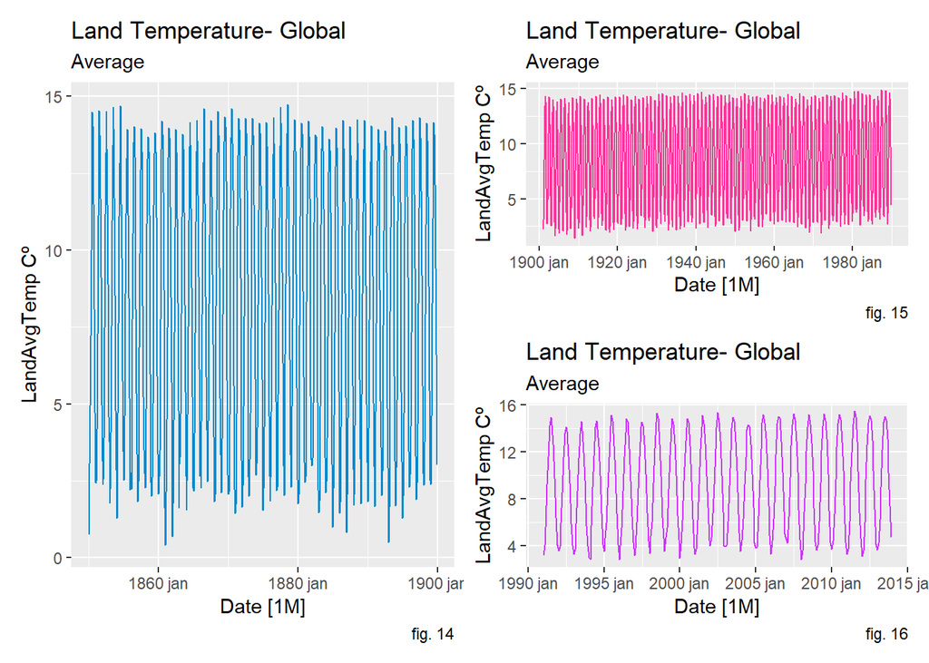

```r
Fig14<- GlobalTemp %>%
  filter(year(Date)>1838, year(Date)<1900) %>%
  autoplot(LandAvgTemp)+
  geom_line(color = '#0088cc')+
  labs(title = "Land Temperature- Global",
       subtitle = "Average",
       y="LandAvgTemp Cº", caption = "fig. 14")

Fig15 <-GlobalTemp %>%
  filter(year(Date)>1900, year(Date)<1990) %>%
  autoplot(LandAvgTemp)+
  geom_line(color = '#ff3399')+
  labs(title = "Land Temperature- Global",
       subtitle = "Average",
       y="LandAvgTemp Cº", caption = "fig. 15")

Fig16 <-GlobalTemp %>%
  filter(year(Date)>1990, year(Date)<2014) %>%
  autoplot(LandAvgTemp)+
  geom_line(color = '#cc33ff')+
  labs(title = "Land Temperature- Global",
       subtitle = "Average",
       y="LandAvgTemp Cº", caption = "fig. 16")
Fig14 + Fig15 / Fig16
```

As the variations around the trend are of similar magnitudes over time, we will use an Additive Decomposition. There are constant ups and downs in terms of seasonality, and the trend is also steadily going upwards, although slowly over time. There is no exponential growth.

### Decomposing using Classical Decomposition

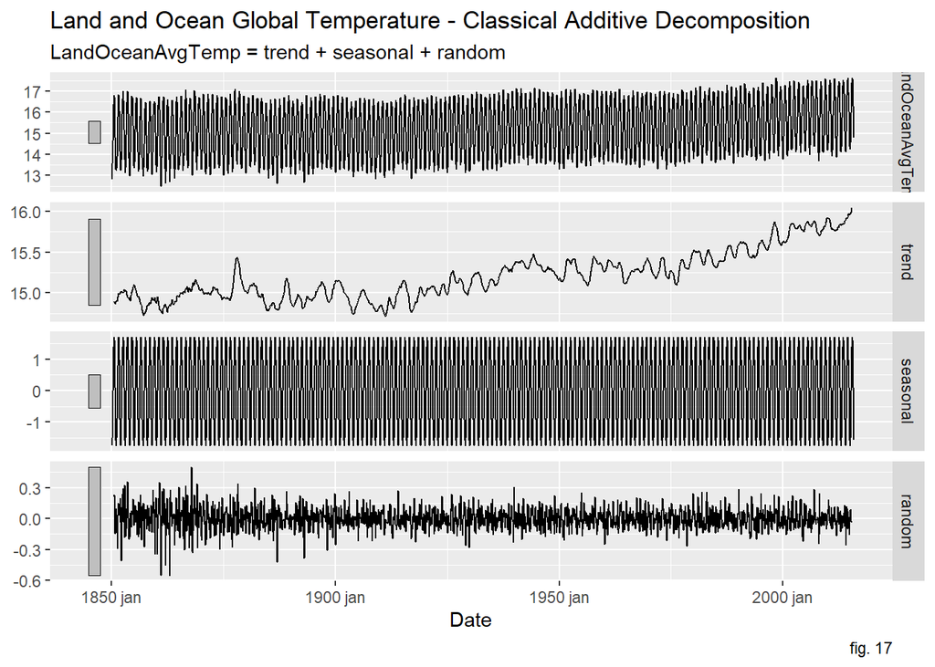

```r
GlobalTemp %>%
  select(LandOceanAvgTemp) -> land_ocean_global_temp

land_ocean_global_temp %>%
  model(classical_decomposition(LandOceanAvgTemp, type = "additive")) %>%
  components() -> classic_decmp

classic_decmp %>%
  autoplot() +
  labs(title = "Land and Ocean Global Temperature - Classical Additive Decomposition", caption = "fig. 17")
```

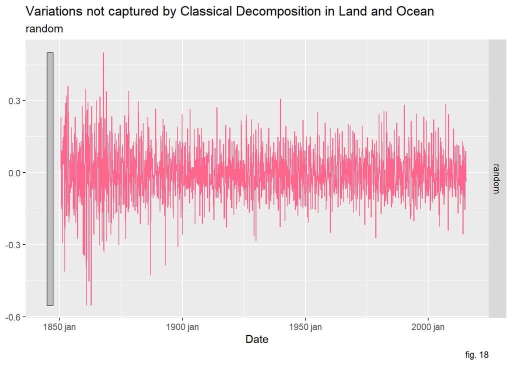

```r
classic_decmp %>%
  autoplot(random, color = '#ff668c') +
  labs(title = "Variations not captured by Classical Decomposition in Land and Ocean", caption = "fig. 18")
```

**How does Classical Decomposition fit our time series?**

Since classical decomposition assumes that the seasonal component repeats from year to year, it fits well with our time series, as temperatures are always higher in summer and lower in winter and this pattern is maintained.

Now, we will try to decompose the series into the Seasonal components, the Trend component and a Remainder, using STL Decomposition.

### Decomposing using STL

```r
dec <- land_ocean_global_temp %>%
  model(stl = STL(LandOceanAvgTemp))

#components(dec)


GlobalTemp %>%
  select(LandAvgTemp) -> land_global_temp


dec2 <- land_global_temp %>%
  model(stl = STL(LandAvgTemp))

#components(dec2)
```

We now isolate the trend and the seasonal adjusted temperatures in graphs.

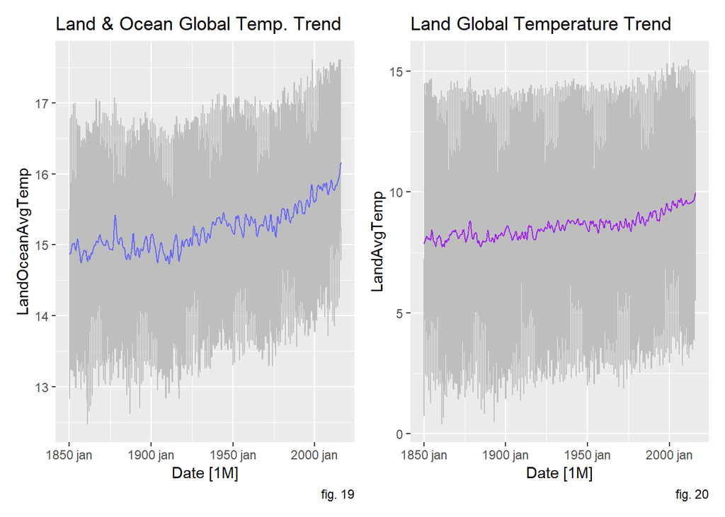

```r
Fig19 <-land_ocean_global_temp %>%
  autoplot(LandOceanAvgTemp, color = 'gray') +
  autolayer(components(dec), trend, color = '#6666ff') +
  ggtitle('Land & Ocean Global Temp. Trend') +
  labs(caption = "fig. 19")


Fig20<- land_global_temp %>%
  autoplot(LandAvgTemp, color = 'gray') +
  autolayer(components(dec2), trend, color = 'purple') +
  ggtitle('Land Global Temperature Trend')+
  labs(caption = "fig. 20")

components(dec) %>%
  filter(year(Date)>1900) -> comp_after1900

Fig21 <-land_ocean_global_temp %>%
  filter(year(Date)>1900) %>%
  autoplot(LandOceanAvgTemp, color = 'gray') +
  autolayer(comp_after1900, trend, color = '#6666ff') +
  ggtitle('Land & Ocean Global Temp. Trend')+
  labs(caption = "fig. 21")

Fig22<- land_global_temp %>%
  autoplot(LandAvgTemp, color = 'gray') +
  autolayer(components(dec2), season_adjust, color = 'purple') +
  ggtitle('Seasonal Adjusted Land Global Temp.')+
  labs(caption = "fig. 22")

(Fig19 + Fig20)
```

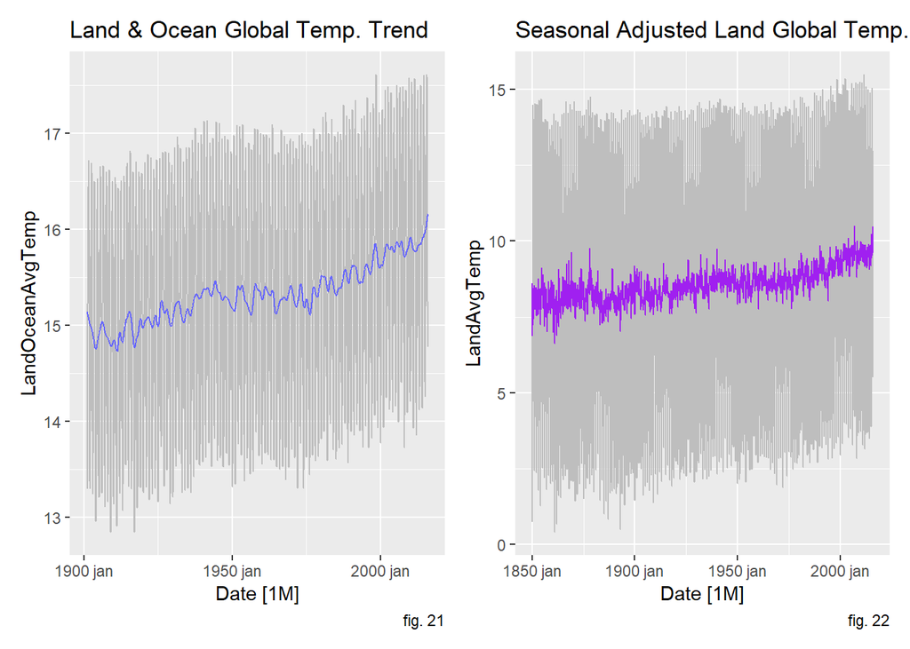

```r
(Fig21 + Fig22)
```

In the third graph, zooming in to more recent years, we can see the evident growth in land and ocean global average temperatures.